# Visualizing and Modeling 2016 US Presidential Election Results

This data setup stolen brazenly from Jennifer Thompson.

```r
knitr::opts_chunk$set(message = FALSE, warning = FALSE)
## Load libraries we'll use
# library(devtools)
# install_github('datadotworld/data.world-r')
library(data.world) ## for querying directly from data.world
library(tidyverse)  ## for data wrangling and piping
library(rms)        ## rms has nice functionality for getting predicted values from model objects
library(reshape2)   ## I know this better than tidyr -@rkahne
state_names = c(
'Alabama' = 01L,
'Alaska' = 02L,
'Arizona' = 04L,
'Arkansas' = 05L,
'California' = 06L,
'Colorado' = 08L,
'Connecticut' = 09L,
'Delaware' = 10L,
'Florida' = 12L,
'Georgia' = 13L,
'Hawaii' = 15L,
'Idaho' = 16L,
'Illinois' = 17L,
'Indiana' = 18L,
'Iowa' = 19L,
'Kansas' = 20L,
'Kentucky' = 21L,
'Louisiana' = 22L,
'Maine' = 23L,
'Maryland' = 24L,
'Massachusetts' = 25L,
'Michigan' = 26L,
'Minnesota' = 27L,
'Mississippi' = 28L,
'Missouri' = 29L,
'Montana' = 30L,
'Nebraska' = 31L,
'Nevada' = 32L,
'New Hampshire' = 33L,
'New Jersey' = 34L,
'New Mexico' = 35L,
'New York' = 36L,
'North Carolina' = 37L,
'North Dakota' = 38L,
'Ohio' = 39L,
'Oklahoma' = 40L,
'Oregon' = 41L,
'Pennsylvania' = 42L,
'Rhode Island' = 44L,
'South Carolina' = 45L,
'South Dakota' = 46L,
'Tennessee' = 47L,
'Texas' = 48L,
'Utah' = 49L,
'Vermont' = 50L,
'Virginia' = 51L,
'Washington' = 53L,
'West Virginia' = 54L,
'Wisconsin' = 55L,
'Wyoming' = 56L,
'District of Columbia' = 11L
)
electoral_votes = c(
'Alabama' = 9,
'Alaska' = 3L,
'Arizona' = 11,
'Arkansas' = 6,
'California' = 55L,
'Colorado' = 9,
'Connecticut' = 7,
'Delaware' = 3,
'Florida' = 29,
'Georgia' = 16,
'Hawaii' = 4,
'Idaho' = 4,
'Illinois' = 20,
'Indiana' = 11,
'Iowa' = 6,
'Kansas' = 6,
'Kentucky' = 8,
'Louisiana' = 8,
'Maine' = 4,
'Maryland' = 10,
'Massachusetts' = 11,
'Michigan' = 16,
'Minnesota' = 10,
'Mississippi' = 6,
'Missouri' = 10,
'Montana' = 3,
'Nebraska' = 5,
'Nevada' = 6,
'New Hampshire' = 4,
'New Jersey' = 14,
'New Mexico' = 5,
'New York' = 29,
'North Carolina' = 15,
'North Dakota' = 3,
'Ohio' = 18,
'Oklahoma' = 7,
'Oregon' = 7,
'Pennsylvania' = 20,
'Rhode Island' = 4,
'South Carolina' = 9,
'South Dakota' = 3,
'Tennessee' = 11,
'Texas' = 38,
'Utah' = 6,
'Vermont' = 3,
'Virginia' = 13,
'Washington' = 12,
'West Virginia' = 5,
'Wisconsin' = 10,
'Wyoming' = 3,
'District of Columbia' = 3
)
elections <-list(
  'Election_2000' = read_csv('https://query.data.world/s/404aq0u4n98hmozughp08npg1') %>% select(County, CountyName, StateName, bush, gore, nader, browne, other),
  'Election_2004' = read_csv('https://query.data.world/s/6mr92w4p92rem4bpbs1ggzcui') %>% select(County, CountyName, StateName, bush, kerry, other),
  'Election_2008' = read_csv('https://query.data.world/s/8pz64y5pglv8dt6umysffgahh') %>% select(County, CountyName, StateName, mccain, obama, other),
  'Election_2012' = read_csv('https://query.data.world/s/29sed01wkb9ljmgg0kgj3ztop') %>% select(County, CountyName, StateName, romney, obama, johnson, stein, other),
  'Election_2016' = read_csv('https://query.data.world/s/dmjcapenh4fg8y7chl5oqgjto') %>% select(County, CountyName, StateName, trump, clinton, johnson, stein, other)
)
```

[output not shown]

```r
elections[[1]]$County <- as.integer(elections[[1]]$County)
```

```
NAs introduced by coercion
```

We want to determine what county characteristics may be predictors of both the county’s final winner in the 2016 presidential election, and the margin of victory by which that candidate won.

# Project Setup

## Loading Data

We’ll load the county characteristics and 2016 presidential election results datasets directly from data.world.

### County Characteristics

These data are mostly from the 2015 [American Community Survey](https://www.census.gov/programs-surveys/acs/), with additional data from other sources. A full data dictionary can be found [here](https://github.com/Data4Democracy/election-transparency/blob/master/data-dictionary/county-level/CountyCharacteristics.md).

```r
library(data.world)
## Set connection (see package README for details: https://github.com/datadotworld/data.world-r)
conn <- data.world('eyJhbGciOiJIUzUxMiJ9.eyJzdWIiOiJwcm9kLXVzZXItY2xpZW50OnJrYWhuZSIsImlzcyI6ImFnZW50….txoXoDeTywrXFO5m1-e_8_G7LBOAxjYwds1c9bxyumli0mT9UH16f5PZZjbDaQr60EinxwpuFVU1s7nzJ0uPxw')
# ## What data tables are available? (both dplyr and data.world have a query(); must specify)
# data_list <- data.world::query(conn,
#                                dataset = 'data4democracy/election-transparency',
#                                query = "SELECT * FROM Tables")
# data_list
countyChar <- data.world::query(conn,
                                dataset = 'data4democracy/election-transparency',
                                query = "SELECT * FROM CountyCharacteristics")
```

### Voter Registration

We also want party registration data from November 2016, queried from the full `PartyRegistration` file. This file includes data pulled from each state’s Secretary of State web site. Full data dictionary is [here](https://github.com/Data4Democracy/election-transparency/blob/master/data-dictionary/county-level/PartyRegistration.md).

Some of the variable names overlap with names in the next dataset; we’ll drop variables that are redundant (state/county names/abbreviations and year/month of registration) and add “Reg” to everything else except state/county keys to clarify that it’s registration info.

```r
voterReg2016 <-
  data.world::query(conn,
                    dataset = 'data4democracy/election-transparency',
                    query = "SELECT * FROM PartyRegistration WHERE Year = 2016 AND Month = 11")
voterReg2016 <- voterReg2016 %>%
  select(-one_of("CountyName", "StateName", "StateAbbr", "Year", "Month", "YearMonth"))
names(voterReg2016) <- ifelse(names(voterReg2016) %in% c('State', 'County'), names(voterReg2016),
                              paste0(names(voterReg2016), 'Reg'))
```

### Presidential Election Results by County

These data are collected from a Harvard research project. A full data dictionary can be found [here](https://github.com/Data4Democracy/election-transparency/blob/master/data-dictionary/county-level/PresidentialElectionResults2016.md).

```r
presResults2016 <- data.world::query(conn,
                                     dataset = 'data4democracy/election-transparency',
                                     query = "SELECT * FROM PresidentialElectionResults2016")
```

## Descriptive Statistics

Let’s join the datasets, calculate some proportions, and look at some basic descriptive statistics.

```r
## Check what variables are in common
# intersect(names(countyChar), names(voterReg2016))
# intersect(names(countyChar), names(presResults2016))
data2016 <- reduce(list(countyChar, voterReg2016, presResults2016),
                   left_join,
                   by = c('County', 'State'))
## Function to quickly calculate a proportion out of TotalPopulation - we'll need to do this a lot
prop_total <- function(x){ x / data2016$TotalPopulation }
data2016 <- data2016 %>%
  ## Calculate lots of proportion variables
  mutate(propMale = prop_total(Male),
         propKids = prop_total(Age0_4 + Age5_9 + Age10_14 + Age15_19),
         propAdultsNoTeens = 1 - propKids,
         ## 15-19 is included in labor force, marital status questions
         totalAdultsWithTeens = Age15_19 + Age20_24 + Age25_34 + Age35_44 + Age45_54 + Age55_59 +
           Age60_64 + Age65_74 + Age75_84 + Age85,
         propAdultsWithTeens = prop_total(totalAdultsWithTeens),
         ## Only >18 included in education questions
         totalAdultsNoTeens = Age20_24 + Age25_34 + Age35_44 + Age45_54 + Age55_59 + Age60_64 +
           Age65_74 + Age75_84 + Age85,
         propElders = prop_total(Age65_74 + Age75_84 + Age85),
         propNMarried = NeverMarried / totalAdultsWithTeens,
         propHispanic = prop_total(Hispanic),
         propWhite = prop_total(White),
         propBlack = prop_total(Black),
         majWhite = propWhite > 0.5,
         majBlack = propBlack > 0.5,
         propNoHS = (EdK8 + Ed9_12) / totalAdultsNoTeens,
         propHS = EdHS / totalAdultsNoTeens,
         propMoreHS = (EdCollNoDegree + EdAssocDegree + EdBachelorDegree + EdGraduateDegree) /
           totalAdultsNoTeens,
         propMfg2015 = MfgEmp2015 / LaborForce,
         propUnemp = Unemployment / LaborForce,
         propLaborForce = prop_total(LaborForce),
         propStein = stein / totalvotes,
         propJohnson = johnson / totalvotes,
         propTrump = trump / totalvotes,
         propClinton = clinton / totalvotes,
         propVoters = totalvotes / totalAdultsNoTeens,
         votedTrump = rPct > 0.5,
         state_EV = electoral_votes[StateName])
## View full data frame
data2016
```

[output not shown]

[output cut: 990 more lines]

## Visualizations!

- I made some small modifications to the code above, which mostly turned out to be useless, anyway.
- I (rkahne) really started doing work around here.
- The goal (for me, right now) is to build out dataframes from the great work done by Jennifer Thompson that can be used with ggplot.
- I’ve done some Very Basic Barplots to get started. I hope other people can take this stuff, modify it, and find some cool and interesting stuff in here.

### Candidate vote totals by State

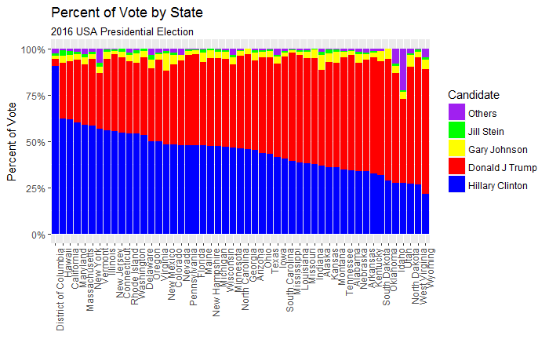

```r
vote_by_state<-select(data2016, StateName, state_EV, clinton, trump, johnson, stein, other) %>%
  melt(id= c('StateName','state_EV')) %>%
  group_by(StateName, state_EV, variable) %>%
  dplyr::summarize(total_vote = sum(value)) %>% # Dunno how plyr got in, but whatever.
  complete(variable) %>%
  ungroup() %>%
  group_by(StateName) %>%
  mutate(sum_total = sum(total_vote, na.rm=T)) %>%
  mutate(proportion = ifelse(is.na(total_vote),NA,paste0(round(total_vote / sum_total, 4)*100,'%')),
         proportion_numeric = total_vote / sum_total) %>%
  select(-sum_total)
candidate_order <- 'clinton' # CHANGE ME
level_order<-(filter(vote_by_state,variable == candidate_order) %>%
                     select(StateName, proportion_numeric) %>%
                     arrange(desc(proportion_numeric)))$StateName
vote_by_state$StateName<- factor(vote_by_state$StateName, levels = level_order)
vote_by_state$variable<-factor(vote_by_state$variable, levels = c('other','stein','johnson','trump','clinton'))
ggplot(vote_by_state, aes(x=StateName, y=total_vote, fill=variable)) +
  geom_bar(stat='identity', position = 'fill') +
  scale_fill_manual(values = c('clinton' = 'blue', 'trump' = 'red', 'stein' = 'green','johnson' = 'yellow','other' = 'purple'),
                    name = 'Candidate',
                    breaks = c('other','stein','johnson','trump','clinton'),
                    labels = c('Others','Jill Stein','Gary Johnson','Donald J Trump','Hillary Clinton')) +
  labs(x = NULL, y = 'Percent of Vote')+
  scale_y_continuous(labels = scales::percent) +
  ggtitle('Percent of Vote by State', subtitle='2016 USA Presidential Election') +
  theme(axis.text.x = element_text(angle = 90, hjust = 1))
```

### Candidate Vote Totals by County Within State

Feel free to play with the variable in this chunk.

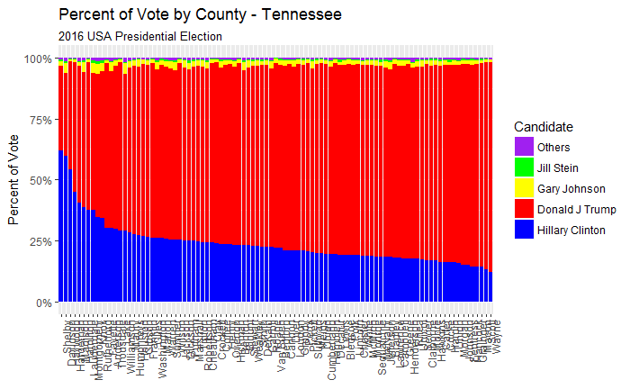

### Ternary Plot

- Let’s try something crazy?!
- Here’s an interesting idea for looking at the county by county results.
  - Utah had a high vote total for Evan McMillin, and this is a way to visualize Utah’s uniqueness.

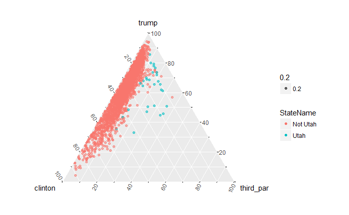

### Party Registration by State

Not all states have partisan registration.

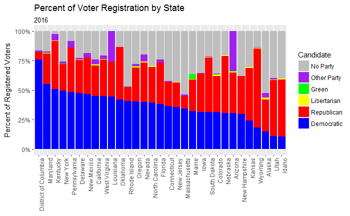

### Partisan Registration by County within State

Feel free to play with the variable in this.

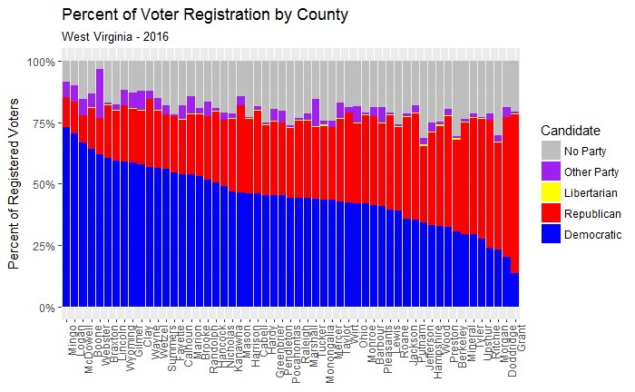

```r
state <- 'West Virginia'
party_registration_c <- filter(data2016, StateName == state) %>%
  select(CountyName, DReg, RReg, OReg, GReg, LReg, NReg) %>%
  melt(id= 'CountyName') %>%
  group_by(CountyName, variable) %>%
  dplyr::summarize(total_reg = sum(value)) %>%
  complete(variable) %>%
  ungroup() %>%
  group_by(CountyName) %>%
  mutate(sum_total = sum(total_reg, na.rm=T)) %>%
  mutate(proportion = ifelse(is.na(total_reg),NA,paste0(round(total_reg / sum_total, 4)*100,'%')),
         proportion_numeric = total_reg / sum_total) %>%
  select(-sum_total)
party_order <- 'DReg' # CHANGE ME
level_order<-(filter(party_registration_c,variable == party_order) %>%
                     select(CountyName, proportion_numeric) %>%
                     arrange(desc(proportion_numeric)))$CountyName
party_registration_c$CountyName<- factor(party_registration_c$CountyName, levels = level_order)
party_registration_c$variable<-factor(party_registration_c$variable, levels = c('NReg','OReg','GReg','LReg','RReg','DReg'))
ggplot(party_registration_c, aes(x=CountyName, y=total_reg, fill=variable)) +
  geom_bar(stat='identity', position = 'fill') +
  scale_fill_manual(values = c('DReg' = 'blue', 'RReg' = 'red', 'GReg' = 'green','LReg' = 'yellow','OReg' = 'purple','NReg' = 'grey'),
                    name = 'Candidate',
                    breaks = c('NReg','OReg','GReg','LReg','RReg','DReg'),
                    labels = c('No Party','Other Party','Green','Libertarian','Republican','Democratic')) +
  labs(x = NULL, y = 'Percent of Registered Voters')+
  scale_y_continuous(labels = scales::percent) +
  ggtitle('Percent of Voter Registration by County', subtitle=paste0(state,' - 2016')) +
  theme(axis.text.x = element_text(angle = 90, hjust = 1))
```

### Voter Turnout by State

- We don’t have great data to do this, becuase the census bracket is from age 15-19, which cuts out two years of voting age.
- Maybe because of this (but maybe not!) there are some states where (voted+registered but didn’t vote) > total voting population.
  - Even if the issue is not the census populations, it could be merely out of date voter registration data.

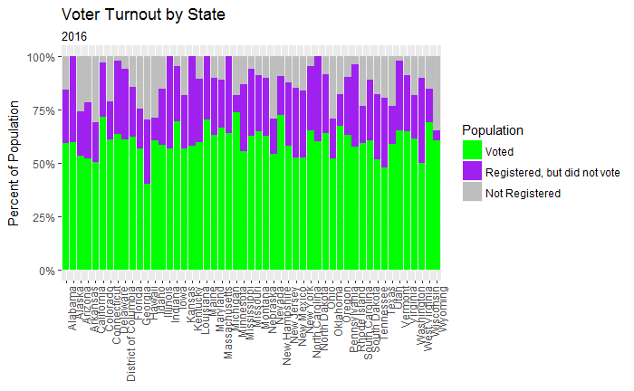

### Voter Turnout by County Within State

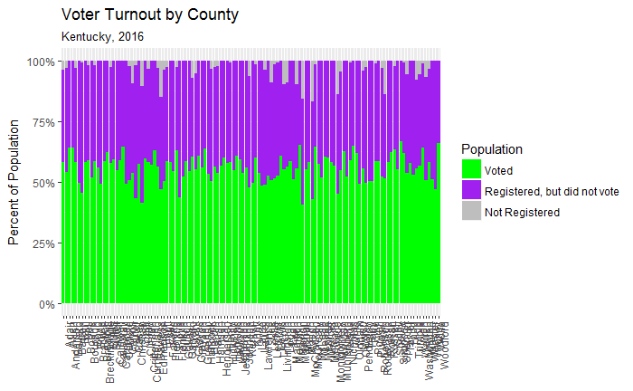

```r
state <- 'Kentucky'
turnout_data_c <- filter(data2016, StateName == state) %>%
  group_by(CountyName) %>%
  dplyr::summarize(total_votes = sum(clinton,trump,johnson,stein,other, na.rm=T),
                   total_reg_no_vote = sum(DReg,RReg,OReg,GReg,LReg,NReg, na.rm=T)-total_votes,
                   total_not_registered = ifelse(sum(TotalPopulation)- sum(Age0_4)- sum(Age5_9)- sum(Age10_14) - sum(Age15_19) -
                     total_reg_no_vote - total_votes<0,NA,sum(TotalPopulation)- sum(Age0_4)- sum(Age5_9)- sum(Age10_14) -
                     sum(Age15_19) - total_reg_no_vote - total_votes)) %>%
  melt(id = 'CountyName') %>%
  group_by(CountyName, variable) %>%
  dplyr::summarize(total_pop = sum(value)) %>%
  complete(variable) %>%
  ungroup() %>%
  group_by(CountyName) %>%
  mutate(sum_total = sum(total_pop, na.rm=T)) %>%
  mutate(proportion = ifelse(is.na(total_pop),NA,paste0(round(total_pop / sum_total, 4)*100,'%')),
         proportion_numeric = total_pop / sum_total) %>%
  select(-sum_total)
turnout_data_c$variable<-factor(turnout_data_c$variable, levels = c('total_not_registered','total_reg_no_vote','total_votes'))
ggplot(turnout_data_c, aes(x=CountyName, y=total_pop, fill=variable)) +
  geom_bar(stat='identity', position = 'fill') +
  scale_fill_manual(values = c('total_votes' = 'green', 'total_reg_no_vote' = 'purple', 'total_not_registered' = 'grey'),
                    name = 'Population',
                    breaks = c('total_votes','total_reg_no_vote','total_not_registered'),
                    labels = c('Voted','Registered, but did not vote','Not Registered')) +
  labs(x = NULL, y = 'Percent of Population')+
  scale_y_continuous(labels = scales::percent) +
  ggtitle('Voter Turnout by County', subtitle=paste0(state,', 2016')) +
  theme(axis.text.x = element_text(angle = 90, hjust = 1))
```

### Victory Margins

- Not quite sure what we are going for, here.

### Demographic / Economic Variables

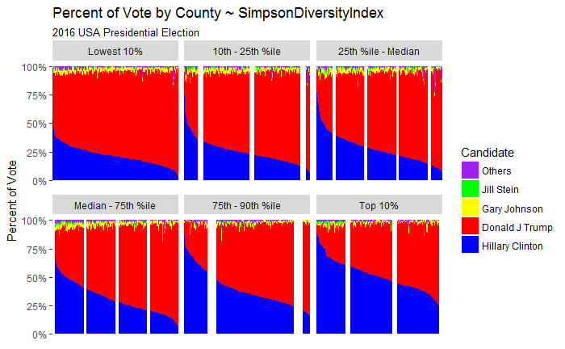